# Parallel in R - basics

February 14, 2015

## Why go parallel?

- Bought a computer after 2010
- Poor coding skills
- Don't know C++
- C++ isn't enough

\(\alpha = \text{non-parallelizable parts}\)

\(p = \text{no. processors}\)

## Parallel in R

**Basics & tools**

1. MapReduce
2. Thinking lapply
3. Package: `parallel`
4. Package: `foreach`
5. Fork or sock?

**Trouble shooting**

1. Caching
2. Debugging in threads
3. Load balancing

## MapReduce - programming model

**Concept**

1. The Map - Map(k1,v1) –> list(k2,v2)
2. Shuffle
3. The Reduce - Reduce(k2, list (v2)) –> list(v3)

**Interpretation**

- Map: calculate the basic core statistic.
- Reorder stuff so reduce can find it
- Reduce: aggregate the statistic from Map into what we want.

## MapReduce - Schematic

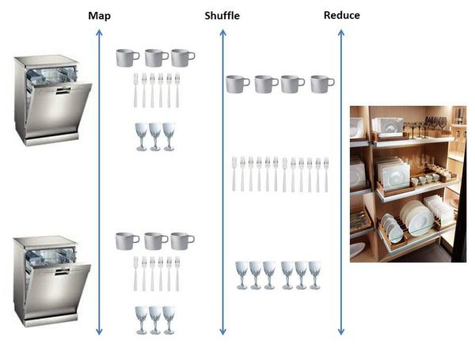

Curtesy of: http://gerardnico.com/wiki/algorithm/map_reduce

## Learning lapply

- Core R
- Simple
- Each element is independent

```r
lapply(1:3, function(x) c(x, x^2, x^3))
```

```
## [[1]]
## [1] 1 1 1
##
## [[2]]
## [1] 2 4 8
##
## [[3]]
## [1]  3  9 27
```

## Package: `parallel`

```r
library(parallel)
no_cores <- detectCores()
base <- 2

# Initiate cluster
cl<-makeCluster(no_cores)
clusterExport(cl, "base")

# Run
parLapply(cl,
          2:4,
          function(exponent)
            base^exponent)
```

```
## [[1]]
## [1] 4
##
## [[2]]
## [1] 8
##
## [[3]]
## [1] 16
```

```r
# Finish
stopCluster(cl)
```

## Package: `parallel` with parSapply

```r
# Simple output
parSapply(cl, 2:4,
          function(exponent)
            base^exponent)
```

```
## [1]  4  8 16
```

```r
# Matrix output with names
parSapply(cl, as.character(2:4),
          function(exponent){
            x <- as.numeric(exponent)
            c(base = base^x, self = x^x)
          })
```

```
##      2  3   4
## base 4  8  16
## self 4 27 256
```

## Package: `foreach`

```r
library(foreach)
library(doParallel)

cl<-makeCluster(no_cores)
registerDoParallel(cl)

foreach(exponent = 2:4,
        .combine = c)  %dopar%
  base^exponent
```

```
## [1]  4  8 16
```

```r
foreach(exponent = 2:4,
        .combine = c)  %dopar%
  base^exponent
```

```
## [1]  4  8 16
```

```r
# Pass two variables
foreach(exponent = 2:4,
        base = 2:4,
        .combine = c) %dopar%
  base^exponent
```

```
## [1]   4  27 256
```

```r
stopCluster(cl)
```

## Package: `foreach` variable scope

```r
test <- function(export = NULL){
  foreach(exponent = 2:4,
          .export = export,
          .combine = c)  %dopar%
    base^exponent
}
test()
```

```
## Error in base^exponent: task 1 failed - "object 'base' not found"
```

```r
# We need to export "base"-variable to avoid error
test("base")
```

```
## [1]  4  8 16
```

## Package: `foreach` creating a lapply result

```r
# Unexpected list?
foreach(exponent = 2:4,
        base = 2:4,
        .combine = list) %dopar%
  base^exponent
```

```
## [[1]]
## [[1]][[1]]
## [1] 4
##
## [[1]][[2]]
## [1] 27
##
##
## [[2]]
## [1] 256
```

## Package: `foreach` creating a lapply result cont.

```r
foreach(exponent = 2:4,
        base = 2:4,
        .combine = list,
        .multicombine = TRUE) %dopar%
  base^exponent
```

```
## [[1]]
## [1] 4
##
## [[2]]
## [1] 27
##
## [[3]]
## [1] 256
```

## Fork or sock?

**FORK**: "to divide in branches and go separate ways"  
System: Unix/Mac  
Environment: Link all

**PSOCK**: Parallel Socket Cluster  
System: Windows  
Environment: Empty

## Fork or sock? cont.

**From Ubuntu 14:10**

```r
cl<-makeCluster(no_cores)
clusterExport(cl, "a")
clusterEvalQ(cl, library(pryr))

parSapply(cl, X = 1:10, function(x) {address(a)}) == address(a)
# [1] FALSE FALSE FALSE FALSE FALSE FALSE FALSE FALSE FALSE FALSE
stopCluster(cl)
```

## Fork or sock? cont.

**From Ubuntu 14:10**

```r
cl<-makePSOCKcluster(no_cores)
clusterEvalQ(cl, library(pryr))
clusterExport(cl, "a")

parSapply(cl, X = 1:10, function(x) address(a)) == address(a)
# [1] FALSE FALSE FALSE FALSE FALSE FALSE FALSE FALSE FALSE FALSE
stopCluster(cl)

cl<-makeForkCluster(no_cores)
parSapply(cl, X = 1:10, function(x) address(a)) == address(a)
# [1] TRUE TRUE TRUE TRUE TRUE TRUE TRUE TRUE TRUE TRUE
stopCluster(cl)
```

## Fork or sock? cont.

**From Ubuntu 14:10**

No memory corruption even with shared

```r
b <- 0
cl<-makeForkcluster(2)
clusterExport(cl, "b")

parSapply(cl, X = 1:10, function(x) {b <- b + 1; b})
# [1] 1 1 1 1 1 1 1 1 1 1
parSapply(cl, X = 1:10, function(x) {b <<- b + 1; b})
# [1] 1 2 3 4 5 1 2 3 4 5
b
# [1] 0
```

## A few tips

**Save one core for the system**

```r
max(1, detectCores() - 1)
```

**Remember to seed correctly with: clusterSetRNGStream**

**Macroparallel (unless memory issues)**

**Microparallel `gputools`**

## Trouble shooting

## Debugging without stop?

`stop()` and you loose

The `tryCatch` - list approach:

```r
foreach(x=list(1, 2, "a"))  %dopar%
{
  tryCatch({
    c(1/x, x, 2^x)
  }, error = function(e) return(paste0("The variable '", x, "'",
                                      " caused the error: '", e, "'")))
}
```

```
## [[1]]
## [1] 1 1 2
##
## [[2]]
## [1] 0.5 2.0 4.0
##
## [[3]]
## [1] "The variable 'a' caused the error: 'Error in 1/x: non-numeric argument to binary operator\n'"
```

## Debugging with files

1. Set outfile: `makeCluster(..., outfile = "par_out.txt")`
2. Use unique files:

```r
foreach(x=list(1, 2, "a"))  %dopar%
{
  cat(dput(x), file = paste0("debug_file_", x, ".txt"))
}
```

## Caching

**Save as you go**

1. Do a digest of settings + function
2. Check if file.exists()
3. Load if exists otherwise run funciton on data and save into file

or use `R.cache`-package

## Caching with digest

```r
cacheParallel <- function(){
  vars <- 1:2
  tmp <- clusterEvalQ(cl,
                      library(digest))

  parSapply(cl, vars, function(var){
    fn <- function(a) a^2
    dg <- digest(list(fn, var))
    cache_fn <-
      sprintf("Cache_%s.Rdata",
              dg)
    if (file.exists(cache_fn)){
      load(cache_fn)
    }else{
      var <- fn(var);
      Sys.sleep(5)
      save(var, file = cache_fn)
    }
    return(var)
  })
}
```

## Caching with digest cont.

```r
system.time(out <- cacheParallel())
```

```
##    user  system elapsed
##    0.01    0.00    5.08
```

```r
out
```

```
## [1] 1 4
```

```r
system.time(out <- cacheParallel())
```

```
##    user  system elapsed
##       0       0       0
```

```r
out
```

```
## [1] 1 4
```

## Load balancing - workload

**parLapply under the hood**

```r
function (cl = NULL, X, fun, ...)
{
    cl <- defaultCluster(cl)
    do.call(c, clusterApply(cl, x = splitList(X, length(cl)),
        fun = lapply, fun, ...), quote = TRUE)
}
```

**Note:** `splitList(X, length(cl))`

## Load balancing - memory

- Remember to use **forks**
- memory.limit()/memory.size() = max cores
- remove any old copies through **rm()**
- force return memory through **gc()**
- skip parallel if memory limit reached

## Load balancing - advanced

**Basic setup**

```r
> rm(list=ls())

> library(pryr)
> library(magrittr)

> a <- matrix(1, ncol=10^4*2, nrow=10^4)
> object_size(a)
1.6 GB
> system.time(mean(a))
   user  system elapsed
  0.338   0.000   0.337
> system.time(mean(a + 1))
   user  system elapsed
  0.490   0.084   0.574


> library(parallel)
> cl <- makeCluster(4, type = "PSOCK")
> system.time(clusterExport(cl, "a"))
   user  system elapsed
  5.253   0.544   7.289
> system.time(parSapply(cl, 1:8,
                        function(x) mean(a + 1)))
   user  system elapsed
  0.008   0.008   3.365
> stopCluster(cl); gc();

> cl <- makeCluster(4, type = "FORK")
> system.time(parSapply(cl, 1:8,
                        function(x) mean(a + 1)))
   user  system elapsed
  0.009   0.008   3.123
> stopCluster(cl)
```

Note the gc() that is needed in order to avoid:

```
Error in mcfork() :
  unable to fork, possible reason: Cannot allocate memory
```

## Load balancing - advanced

**The PSOCK problem**

```r
> cl <- makeCluster(8, type = "PSOCK")
> system.time(clusterExport(cl, "a"))
   user  system elapsed
 10.576   1.263  15.877
> system.time(parSapply(cl, 1:8, function(x) mean(a + 1)))
Error in checkForRemoteErrors(val) :
  8 nodes produced errors; first error: cannot allocate vector of size 1.5 Gb
Timing stopped at: 0.004 0 0.389
> stopCluster(cl)

> cl <- makeCluster(8, type = "FORK")
> system.time(parSapply(cl, 1:8, function(x) mean(a + 1)))
   user  system elapsed
  0.014   0.016   3.735
> stopCluster(cl)
```

## Load balancing - advanced

**Even FORKs won't save you in the end**

```r
> a <- matrix(1, ncol=10^4*2.1, nrow=10^4)
> cl <- makeCluster(8, type = "FORK")
> parSapply(cl, 1:8, function(x) {
+   b <- a + 1
+   mean(b)
+   })
Error in unserialize(node$con) : error reading from connection
```